# Support Vector Machines for Binary Classification

> “Support Vector Machines … are a very sophisticated idea … which should be in the tool bag of every civilized person.” - Patrick Winston [^1]

## Introduction

Support vector machine (SVM) learning is a supervised learning technique that may be used as a binary classification system or to find regression formulae. Support vector machines are a “maximum margin classifier. SVM finds the separating hyperplane with the maximum margin to its closest data points.” [^2]

Although there are many different mathematical approaches to solving SVM, many which include kernels, Let us first describe the Linear SVM. Consider a situation where we need to distinguish between two circumstances.

In an imaginary biochemistry laboratory, researchers find a novel enzyme found in different tissues throughout the human body. Biochemists purify the enzyme from several cadavers and several different tissue samples. There is literature that shows this newly found enzyme has two isozymes, Alpha has a high activity and Gamma has a lower activity. It know seems like a simple task to learn which isozyme is in which tissue samples, investigate the enzyme activity and look for the production of a fluorescent compound. You plot the enzyme activities found in the lab.

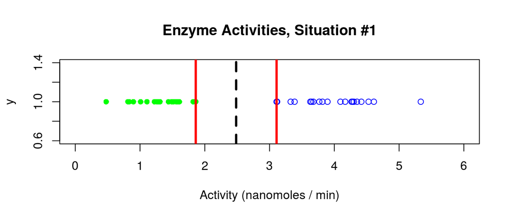

In the figure above it is easy to see that the isozymes have distinct activities. In this case, the isozymes are separated by activity alone. In this first figure, it is said the data is “linearly separabale”. [^3] To state the obvous, the two groups are linearly separable by the fact that a single straight line can partition the data.

Incidentally, in Patrick Winston’s lecture on SVM, he calls SVM the “widest street approach”. There are many possible streets which can be traced BUT the goal is to find the *widest* street. This leads to the best separation and the fewest number of collisions.

However, in the figure above, we can see that linearly separable may not be clear since there are an infinite number of lines with varying slopes that separate the groups.

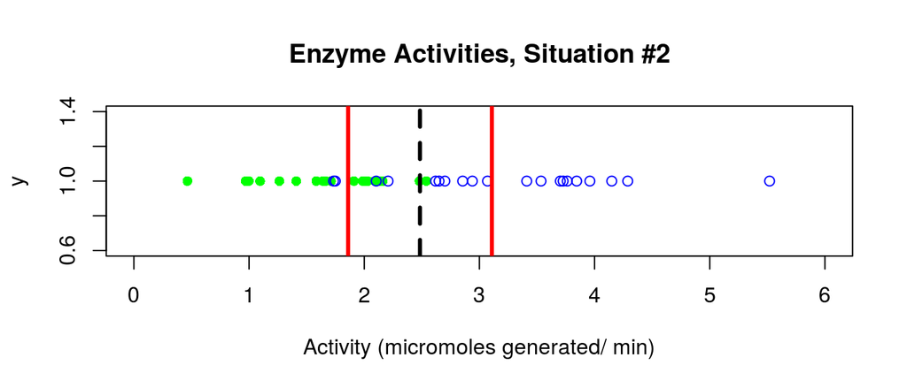

In the case above, the activities overlap hence determining which isozyme is Alpha or Gamma is more difficult.

The same is true of an n-dimensional system.

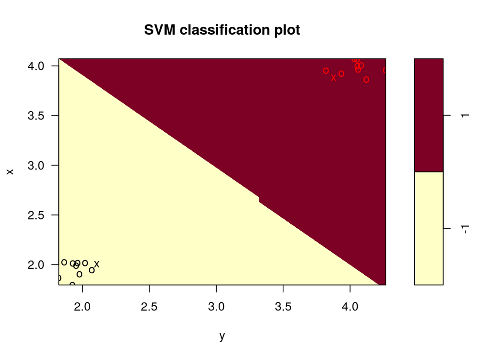

The first mention of an SVM like system is by Vapnik and Lerner in 1963, where the two described an implementation of a non-linear generalization called a Generalized Portrait algorithm.[^4] As research has progressed, the types and complexity of SVM implementations have grown to encompass many circumstances. The ability of SVM to deal with different problems and handle different decision boundary shapes has made SVM a potent tool.

For example, this experiment has chosen to investigate three possible decision boundary shapes for the two-class protein data. The three mathematical constructs which will be tested are:

1. Linear hyperplane (also known as “vanilla”),
2. Curvilinear or polynomial hyperplane and,
3. A radial basis function hyperplane.

Four common SVM kernel formulae investigated are:

1. Linear: $K(x, ~y) ~=~ w^T x + b$
- The linear kernel does not transform the data at all.
2. Polynomial: $K(x_i, ~y) ~=~ ( \gamma ~x_i^T ~x_j ~+~ r)^{\Large d}, ~~ \gamma > 0$
- The polynomial kernel has a straightforward non-linear transform of the data.
- Such that $~\gamma, ~r$, and $d$ are kernel parameters.
3. Radial Basis Function (RBF): $K(x_i, x_j) ~=~ exp ( - {\gamma} \parallel x_i^T - x_j \parallel ^2 ), ~~ \gamma >0$
- The Gaussian RBF kernel which performs well on many data and is a good default
4. Sigmoidal: $K(x, y) ~=~ {\tanh} (\gamma~ x^T ~ y ~+~ r ), ~~ \gamma >0$
- Incidentally, The sigmoid kernel produces an SVM analogous to the activation function similar to a [perceptron] with a sigmoid activation function.[^5]

**It is essential to note**, at this time, there are no reliable rules for which kernel, i.e., boundary shape, to use with any given data set.

Plots of 4 common SVM boundary shapes:

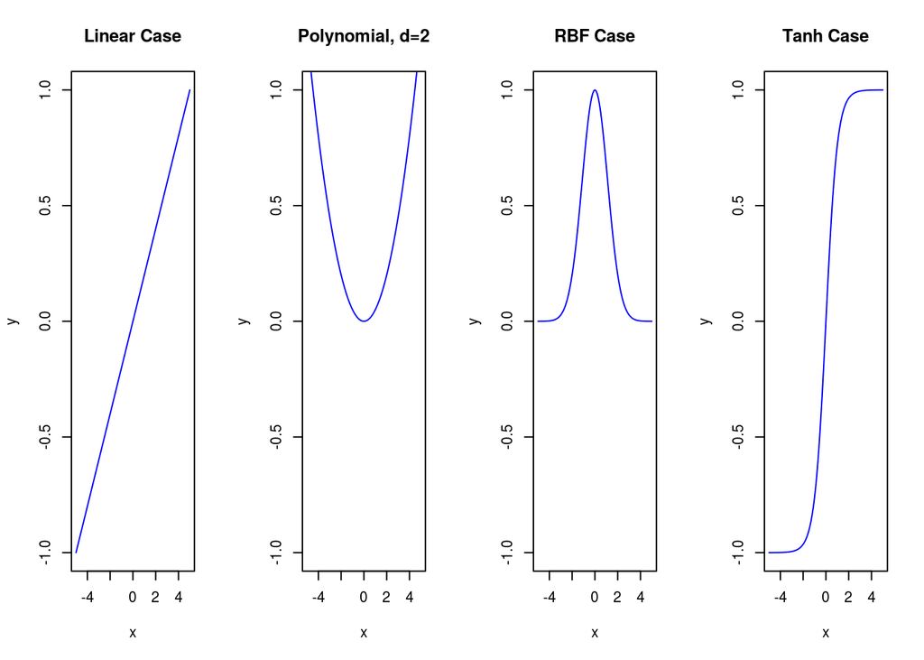

### SVM-Linear

The simplest form of SVM utilizes a hyperplane as a separating element between the positive and control protein observations. This type of implementation is denoted as SVM-Linear (svm-lin) in this report. Here the mathematics is more easily described and can even be shown with a simple 2-dimensional graphic.

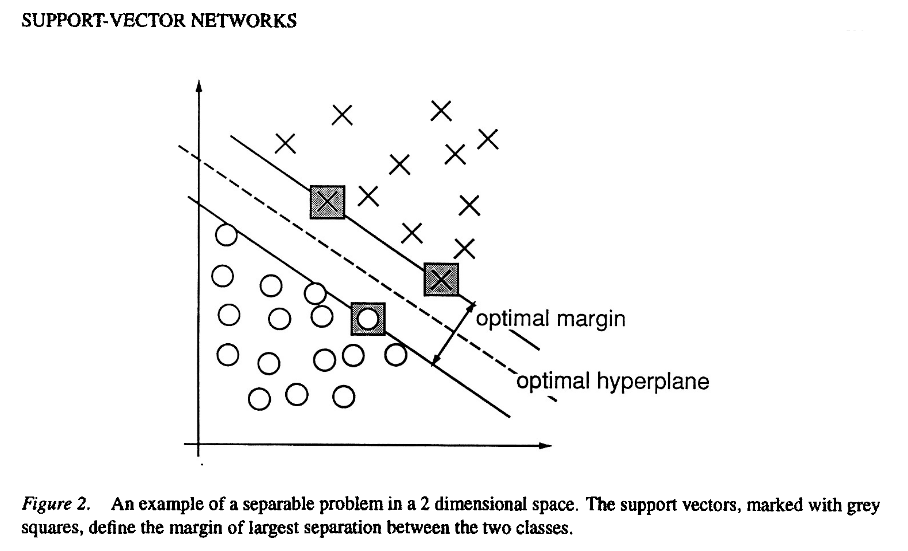

Given a set of labeled pairs of data:

$$\{(X_1, ~y),~ ...,~ (X_m, ~y)\},~~~ y \in \{1, ~-1\}, ~~~ where ~X^{m~x~n} \in \Re$$

For mathematical convenience, the labels are a set of values 1 or -1.

Therefore, we may write.

$$~~~f(x_i) = \left\{ \begin{array}{cc} \geq 0; ~y = 1 \\ ~< 0; ~y = -1 \end{array} \right.$$

This is no different than is currently done in beginner level algebra. As is shown in the example below, the same is true for higher-dimensional problems.

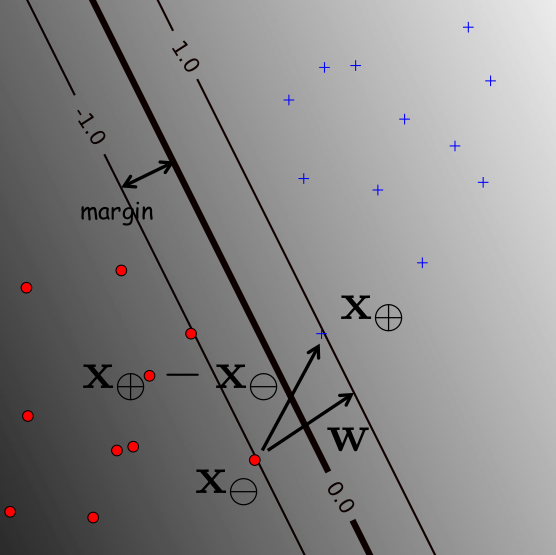

In this experiment, three implementations of SVM have been used. The three are denoted as SVM-Linear (SVM-lin), SVM-Polynomial (SVM-poly), and SVM-Radial Basis Function (SVM-rbf).

Yet another measurable difference that was investigated in this experiment was the use of a kernel transformation. It is conceivable to envision a hyperplane with no transformations utilized. Alternatively, the kernel transformations of original data can be used to increase the ability of the function to differentiate between positively and negatively labeled samples. A mathematical treatment can be found by Christopher Burges.[^6]

As the usage of SVM grew, different issues presented problems for defining and coding the decision boundary were found. In the simplest case, the data points that sit along the support vector are nicely and neatly on the positive or the negative side. This is known as a hard margin which delineates the decision boundary. In reality, the decision boundary may include positive or negative datapoints that sporadically cross the boundary. In the circumstance where the decision boundary has similar points on either side, a penalty may be enlisted to deter the mathematics from choosing a boundary that includes too many misfit datapoints. In 1995, Support Vector Machines were described by Vladimir Vapnik and Corinna Cortes while at Bell Labs dealt with the soft-margin that occurs in the above situation.[^7]

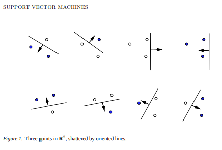

SVM is a non-parametric approach to regression and classification models.

What is Non-parametric?

For that matter, what is parametric learning and models. Just as we have learned that machine learning models can be supervised, unsupervised, or even semi-supervised another characteristic between machine learning models is whether they are parametric or not.

In Webster’s dictionary [^8] states a *parameter* is

> 1. Estimation of values which enter into the equation representing the chosen relation
> 2. [An] independent variable through functions of which other functions may be expressed - Frank Yates, a 20th-century statistician

Another excellent explanation of this idea includes;

> Does the model have a fixed number of parameters, or does the number of parameters grow with the amount of training data? The former is called a parametric model, and the latter is called a non-parametric model. Parametric models have the advantage of often being faster to use, but the disadvantage of making stronger assumptions about the nature of the data distributions. Non-parametric models are more flexible, but often computationally intractable for large datasets.[^9]

Since Support Vector Machines are best described as a system where increasing the amount of training data, the numbers of parameters may grow as well. Therefore SVM is a non-parametric technique. Considering this idea in more detail, the estimation of the decision boundary does not entirely rely on the estimation of independent values (i.e., the values of the parameters). SVM is fascinating because the decision boundary may only rely on a small number of data points, otherwise known as support vectors.

In short, one guiding idea of SVM is a geometric one. In a binary-class learning system, the metric for the concept of the “best” classification function can be realized geometrically[^10] by using a line or a plane (more precisely called a hyperplane when discussing multi-dimensional datasets) to separate the two labeled groups. The hyperplane that separates the labeled sets is also known as a decision boundary.

This decision boundary can be described as having a hard or soft margin. As one might suspect, there are instances where the delineation between the labels is pronounced when this occurs decision boundary produces a hard margin. Alternatively, when the demarcation between the labeled groups is not so well defined by a straight and rigid line, the decision boundary provided is a soft margin. In either case, researchers have built up mathematics to deal with hard and soft margins. As an aside, the use of penalization is one method for coping with data points that impinge on the boundary hyperplane.

Patrick Winston calls it the ‘widest street approach’. - See: [Patrick Winston](https://www.youtube.com/watch?v=_PwhiWxHK8o)

By introducing a “soft margin” instead of a hard boundary, we can add a slack variable xi to account for the amount of a violation by the classifier, which later can be minimized.